# Evaluating observed weather in Auckland

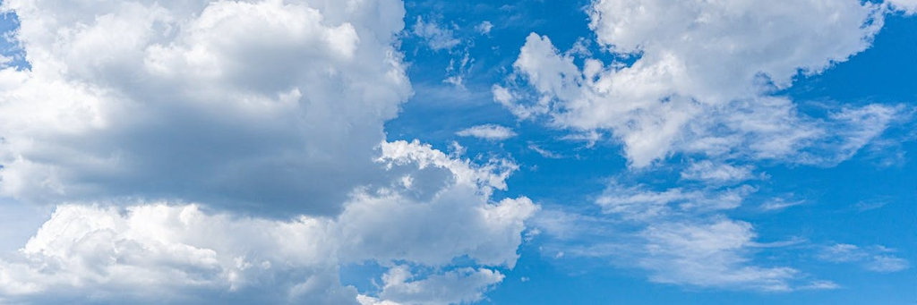

This report summarises data from personal observations of the weather in Auckland.  
The observations include time of day, whether it was raining, how cloudy the sky was, and an estimated temperature (Celsius).

## Do clouds mean rain?

My main thought while collecting this data was how strong the correlation between cloudiness and rain would be, so let’s have a look!

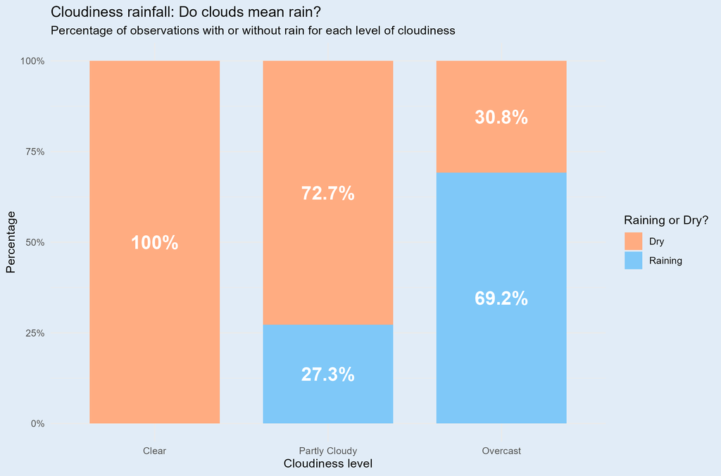

Plot 1

As we can see above, the data generally align with expectations: no rain on clear observations, just under a third of partly cloudy observations had rain, and overcast observations had nearly 70% rain!

## How did the temperature change?

Seeing as the cloudiness and rainfall data went as expected, how about we look at how the temperature changed over time?

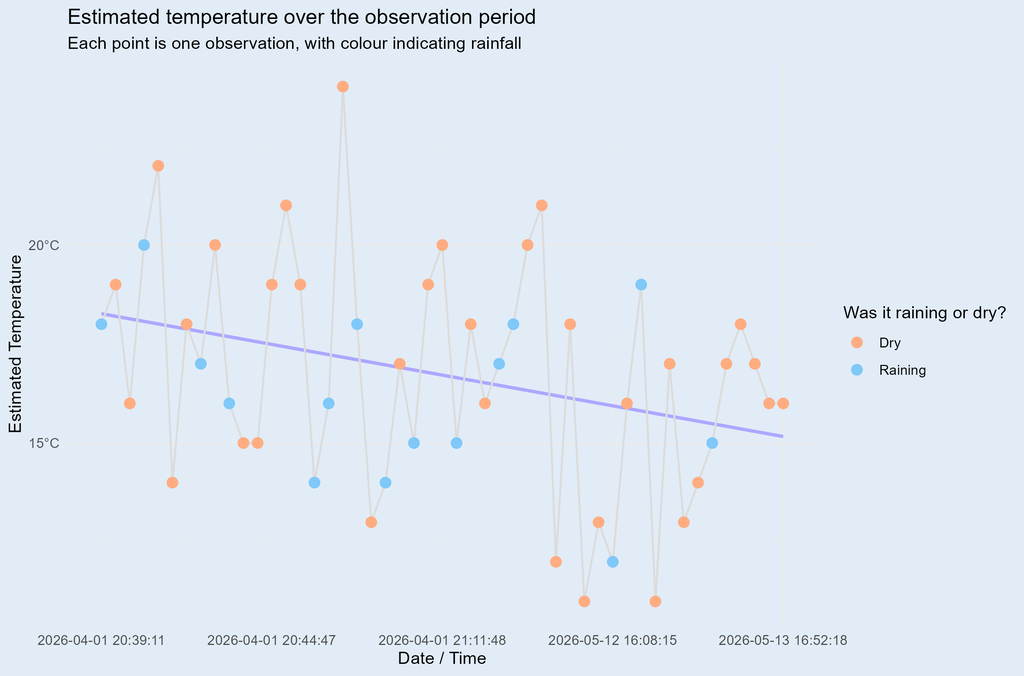

Plot 2

## How about at the different times of day?

Let’s take a closer look at when the temperature data was collected during the day.

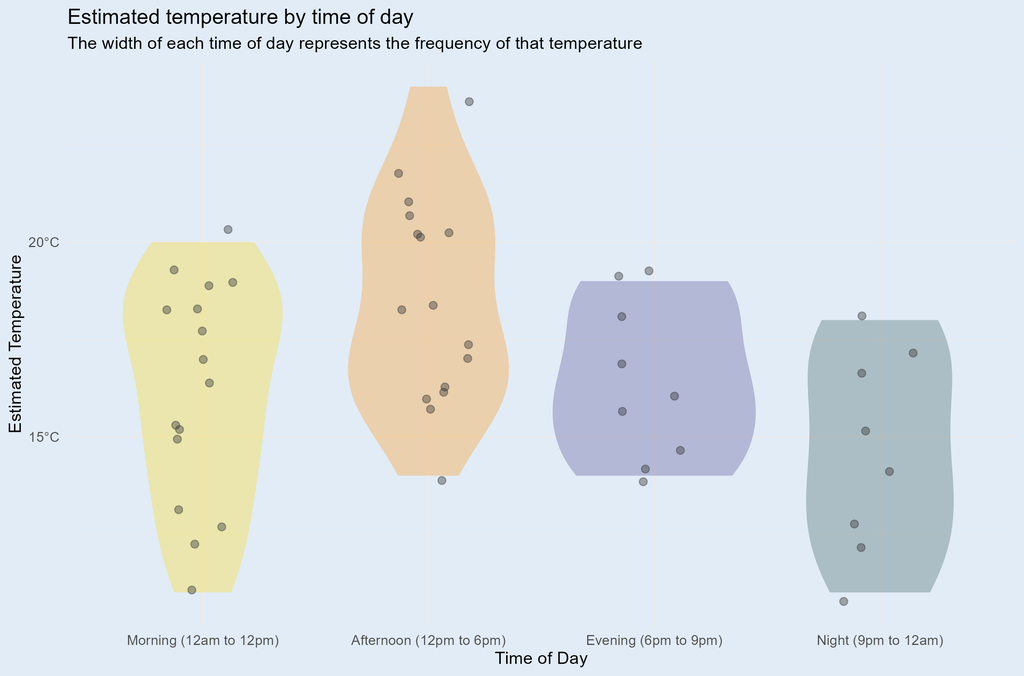

Plot 3